# The issue of ice

Robert Schlegel

2021-03-23

## Introduction

While putting together the global analysis of historic marine cold-spells (MCSs) we came to learn that simply inverting the marine heatwave (MHW) algorithm did technically work, but created a couple of unexpected issues that needed to be addressed. These issues stem from the fact that on our planet seawater freezes at roughly -1.8°C. The first, and much more wide-spread issue, was that for most of the near-ice pixels on the planet, the average intra-annual (within one year) variance in sea-surface temperature (SST) could be very low (e.g. +-0.2°C). The MHW algorithm works on quantiles, and these maths tend not to be very effective with such a small range in values. Indeed, what does it really matter if a MHW/MCS is detected because of a change of 0.05°C from the seasonally expected average? Can that possibly have any effect on local bio/ecology? One obvious solution to this issue is to not apply the MHW/MCS algorithm to near-ice pixels, but ignoring the issue is not a satisfactory response to it. The other much less common issue we found is that in some regions of the ocean that do experience a reasonable range in intra-annual SST, it can be possible that the category system will not be able to detect the more intense category of events because the the thresholds for these events may be colder than -1.8°C. I know that sentence probably didn’t make any sense, which is why we will be providing examples below that illustrate these two issues and outline the steps that one may take to address them. All of the code necessary to do so is documented and we welcome anyone interested in this issue to use the code themselves in any projects, or to contact us as desired.

Before we get into the weeds on all of these technical issue I must reiterate what is stated in the paper that this vignette was written to accompany. The authors all agreed that ultimately, for a global analysis, it was better to use the “original” definition from Hobday et al. (2016) with a 10th percentile threshold (rather than 90th percentile for MHWs) because this would provide globally consistent and comparable results. It was also decided to stick to the category convention laid out in Hobday et al. (2018). The options that are laid out below are done so with the intention that they may be more useful to researchers investigating MCSs at a more regional scale. Or perhaps for researchers that need to work in near-ice areas and are not satisfied with how the MCS algorithm functions there.

In the following sections we will first look at considerations for how to deal with the less common issue of when it becomes impossible to detect more intense categories of MCSs in a time series. Building off of the theory demonstrated in that section we will then look at what to do about MCS detection in near-ice areas that experience very little intra-annual variance in SST. We will wrap up this vignette by looking at how much these tweaks to the algorithm can have a global effect, and how sensitive global results are to these tweaks. It must be noted that all of the following proposed changes only affect the category results, not the MCS metrics themselves (e.g. duration, maximum intensity, rate of onset).

```r
# The libraries used in this vignette
.libPaths(c("~/R-packages", .libPaths()))
source("code/functions.R")
```

## Impossible categories

Reading through the paper that this vignette accompanies, one will perhaps have noticed how infrequently category IV Extreme MCSs occur in the global data. They are much more rare than in MHWs. This is not however what we mean when we refer to “impossible categories”. For much of the ocean that never experiences a category IV MCS this is because there is either not enough variance in the time series or perhaps a positive skew in the data. It is still technically possible that most of the ocean could experience the full range of MCS categories, but for some areas the temperature necessary for an anomaly to be labeled as a category IV event would be colder than -1.8°C. The following figure shows the per pixel temperature threshold necessary for a category IV event.

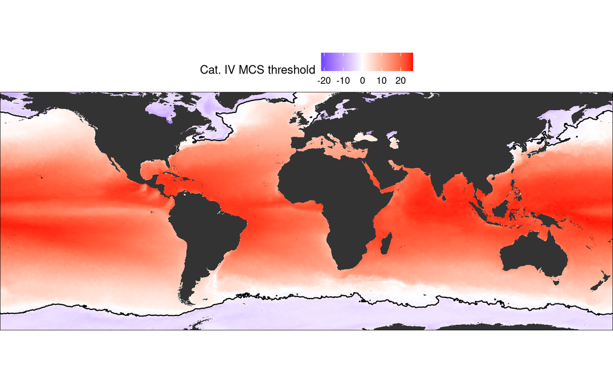

**Figure S1:** The threshold (C) a temperature anomaly must reach before being labeled as a category IV ‘Extreme’ MCS. The black contour shows the freezing point of water (-1.8C) below which seawater tmeperatures cannot exceed.

```r
# Function for loading and extracting the lowest MCS threshold per pixel
MCS_thresh_func <- function(lon_step){
  MCS_df <- readRDS(MCS_lon_files[lon_step])
  MCS_thresh <- MCS_df %>%
    dplyr::select(-cat) %>%
    unnest(event) %>%
    filter(row_number() %% 2 == 1) %>%
    unnest(event) %>%
    mutate(diff = thresh - seas,
           thresh_2x = thresh + diff,
           thresh_3x = thresh_2x + diff,
           thresh_4x = thresh_3x + diff) %>%
    group_by(lon, lat) %>%
    summarise(thresh_4x = min(thresh_4x, na.rm = T), .groups = "drop")
  rm(MCS_df); gc()
  return(MCS_thresh)
}

# Load all of the max Cat 4 thresholds
doParallel::registerDoParallel(cores = 50)
MCS_thresh <- plyr::ldply(1:1440, MCS_thresh_func, .parallel = T, .paropts = c(.inorder = FALSE))
saveRDS(MCS_thresh, "data/MCS_thresh.Rds")
```

Note the black contour in the above figure. Any area (blue) within this contour cannot experience a category IV MCS (or perhaps even categories II or III) because the temperature necessary is below the freezing point of seawater (-1.8°C). For much of this area these are the near-ice regions of the ocean that are more problematic for another reason, which we will discuss in the following section. For some areas of the ocean however, such as the Nova Scotian Shelf that experiences very little sea-ice in a given year, it is surprising that this issue can be found so far from the poles. This occurs because the inter-annual variance can be so great in some areas that the method for determining the category thresholds creates unachievably large differences between categories. We will use a pixel from the coast North of Florida in the United States to illustrate this issue, and to show a potential fix for it.

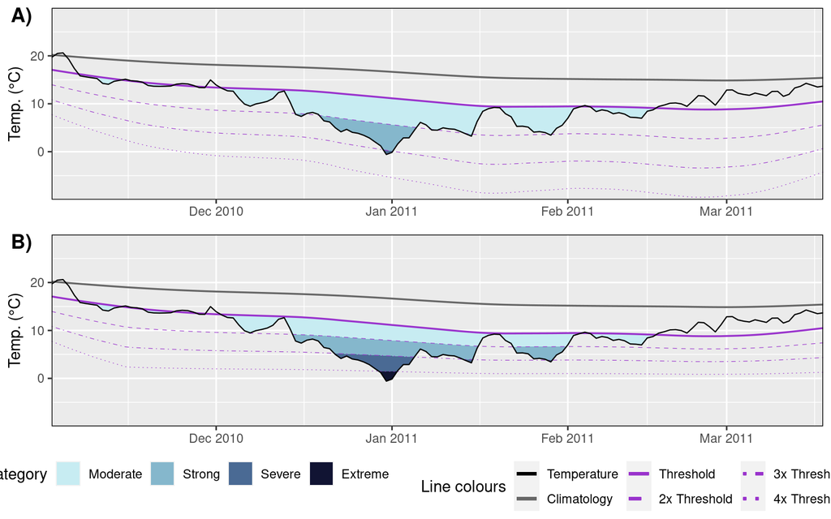

**Figure S2.1:** The difference in MCS categories for the same event when the Category IV threhsold limit is adjusted for the bottom limit of -1.8C, rather than what the original category convention would dictate.

```r
# Extract an extreme example from the barrier islands North of Florida
FL_SST <- tidync(OISST_files[which(lon_OISST == -75.875)]) %>%
  hyper_tibble() %>%
  dplyr::rename(t = time, temp = sst) %>%
  filter(lat == 35.375) %>%
  mutate(t = as.Date(t, origin = "1970-01-01"))

# Detect MCSs climatology
FL_clim <- detect_event(ts2clm(FL_SST, climatologyPeriod = c("1982-01-01", "2011-12-31"), pctile = 10),
                        coldSpells = T)$climatology %>%
  # The original category method
  mutate(diff = thresh - seas,
         thresh_2x = thresh + diff,
         thresh_3x = thresh_2x + diff,
         thresh_4x = thresh_3x + diff) %>%
  # The proposed fix for "impossible" categories
  mutate(diff_new = case_when(thresh_4x+diff <= -1.8 ~ -(thresh+1.8)/4, TRUE ~ diff),
         thresh_2x_new = thresh + diff_new,
         thresh_3x_new = thresh_2x_new + diff_new,
         thresh_4x_new = thresh_3x_new + diff_new) %>%
  # Another fix explained in the following section
  mutate(thresh_5x = ifelse(thresh < -1.5, thresh, -1.5))

# Further subset for correct hatching
FL_clim_sub <- FL_clim %>%
  filter(event_no == 69)

# Top left panel: original categories
fig_S2a <- FL_clim  %>%
  filter(t >= min(FL_clim_sub$t)-30,
         t <= max(FL_clim_sub$t)+30) %>%
  ggplot(aes(x = t)) +
  geom_flame(aes(y = thresh, y2 = temp, fill = "Moderate"), n = 5, n_gap = 2) +
  geom_flame(aes(y = thresh_2x, y2 = temp, fill = "Strong")) +
  geom_flame(aes(y = thresh_3x, y2 = temp, fill = "Severe")) +
  geom_flame(aes(y = thresh_4x, y2 = temp, fill = "Extreme")) +
  # geom_ribbon_pattern(data = FL_clim_sub, aes(ymin = seas, ymax = temp),
  #                     pattern = 'stripe', fill = NA, colour  = 'black') +
  geom_line(aes(y = thresh_2x, col = "2x Threshold"), size = 0.2, linetype = "dashed") +
  geom_line(aes(y = thresh_3x, col = "3x Threshold"), size = 0.2, linetype = "dotdash") +
  geom_line(aes(y = thresh_4x, col = "4x Threshold"), size = 0.2, linetype = "dotted") +
  geom_line(aes(y = seas, col = "Climatology"), size = 0.6) +
  geom_line(aes(y = thresh, col = "Threshold"), size = 0.6) +
  geom_line(aes(y = temp, col = "Temperature"), size = 0.4) +
  # geom_hline(aes(yintercept = -1.8), size = 1, colour = "hotpink") +
  scale_colour_manual(name = "Line colours", values = lineCol,
                      breaks = c("Temperature", "Climatology", "Threshold",
                                 "2x Threshold", "3x Threshold", "4x Threshold")) +
  scale_fill_manual(name = "Category", values = fillCol, breaks = c("Moderate", "Strong", "Severe", "Extreme")) +
  scale_x_date(date_labels = "%b %Y", expand = c(0, 0)) +
  scale_y_continuous(limits = c(-10, 30), breaks = c(0, 10, 20), expand = c(0, 0)) +
  guides(colour = guide_legend(override.aes = list(linetype = c("solid", "solid", "solid", "dashed", "dotdash", "dotted"),
                                                   size = c(1, 1, 1, 1, 1, 1)))) +
  labs(y = expression(paste("Temp. (°C)")), x = NULL) +
  theme(panel.border = element_rect(colour = "black", fill = NA))
# fig_S2a

# Top middle panel: the categories corrected for -1.8C
fig_S2b <- FL_clim  %>%
  filter(t >= min(FL_clim_sub$t)-30,
         t <= max(FL_clim_sub$t)+30) %>%
  ggplot(aes(x = t)) +
  geom_flame(aes(y = thresh, y2 = temp, fill = "Moderate"), n = 5, n_gap = 2) +
  geom_flame(aes(y = thresh_2x_new, y2 = temp, fill = "Strong")) +
  geom_flame(aes(y = thresh_3x_new, y2 = temp, fill = "Severe")) +
  geom_flame(aes(y = thresh_4x_new, y2 = temp, fill = "Extreme")) +
  # geom_ribbon_pattern(data = FL_clim_sub, aes(ymin = seas, ymax = temp),
  #                     pattern = 'stripe', fill = NA, colour  = 'black') +
  geom_line(aes(y = thresh_2x_new, col = "2x Threshold"), size = 0.2, linetype = "dashed") +
  geom_line(aes(y = thresh_3x_new, col = "3x Threshold"), size = 0.2, linetype = "dotdash") +
  geom_line(aes(y = thresh_4x_new, col = "4x Threshold"), size = 0.2, linetype = "dotted") +
  geom_line(aes(y = seas, col = "Climatology"), size = 0.6) +
  geom_line(aes(y = thresh, col = "Threshold"), size = 0.6) +
  geom_line(aes(y = temp, col = "Temperature"), size = 0.4) +
  # geom_hline(aes(yintercept = -1.8), size = 1, colour = "hotpink") +
  scale_colour_manual(name = "Line colours", values = lineCol,
                      breaks = c("Temperature", "Climatology", "Threshold",
                                 "2x Threshold", "3x Threshold", "4x Threshold")) +
  scale_fill_manual(name = "Category", values = fillCol, breaks = c("Moderate", "Strong", "Severe", "Extreme")) +
  scale_x_date(date_labels = "%b %Y", expand = c(0, 0)) +
  scale_y_continuous(limits = c(-10, 30), breaks = c(0, 10, 20), expand = c(0, 0)) +
  guides(colour = guide_legend(override.aes = list(linetype = c("solid", "solid", "solid", "dashed", "dotdash", "dotted"),
                                                   size = c(1, 1, 1, 1, 1, 1)))) +
  labs(y = expression(paste("Temp. (°C)")), x = NULL) +
  theme(panel.border = element_rect(colour = "black", fill = NA))
# fig_S2b
ggpubr::ggarrange(fig_S2a, fig_S2b, ncol = 1, nrow = 2, common.legend = T, legend = "bottom", labels = c("A)", "B)"))
```

## Chilly all year long

In the previous section we looked at how some areas of the ocean, which never normally freeze, have sub-zero temperature thresholds for MCS category classification. This is not ideal and is an artefact of inverting the MHW algorithm. It is however that opinion of the authors that the benefits of the use of the inverted MHW algorithm for MCS detection far outweighs the problems. We proposed a fix to this issue, which has been hard-coded into the R version of the source code, and anyone may apply it with the `category(data, MCScorrect = T)` argument.

In this section we will focus on the other issue of detecting MCSs globally. In near-ice areas of the ocean there is little thermal variance and so the utility of the MCS algorithm begins to break down. This is particularly noticeable for the category system. The way the system currently works it is nearly impossible to detect category II or more intense events in near-ice areas. As demonstrated above, this is because the category thresholds go below -1.8°C. So then one thinks to apply the same fix above to the near-ice pixels, meaning that we adjust the categories based on the limit of -1.8°C. This is technically easy to do, but leads to the emergence of a new problem. When the range in temperatures is very low, all of the newly adjusted thresholds for the categories practically sit on top of each other. This effectively changes the problem from being only able to detect category I events, to being only able to detect category IV events. So we had a think about it and decided that the best way to address this issue was to introduce a new category V “Ice”. This would be determined whenever any single `thresh` value during a MCS was -1.5°C or cooler. The following figure demonstrates what these two different adjustments look like on the same event.

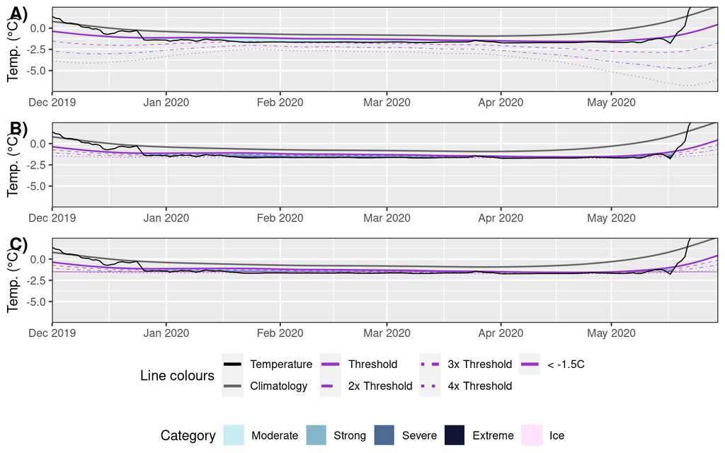

**Figure S2.2:** The difference in MCS categories for the same event when the Category IV threhsold limit is adjusted for the bottom limit of -1.8C, or when any values below -1.5C are considered ‘Ice’ events.

```r
# Extract an ice-edge data point to show the effect of ice category
ice_SST <- tidync(OISST_files[which(lon_OISST == 147.875)]) %>%
  hyper_tibble() %>%
  mutate(time = as.Date(time, origin = "1970-01-01")) %>%
  dplyr::rename(t = time, temp = sst) %>%
  filter(lat == 59.375)

# Calculate clims etc.
ice_clim <- ts2clm(ice_SST, climatologyPeriod = c("1982-01-01", "2011-12-31"), pctile = 10) %>%
  mutate(diff = thresh - seas,
         thresh_2x = thresh + diff,
         thresh_3x = thresh_2x + diff,
         thresh_4x = thresh_3x + diff) %>%
  mutate(diff_new = case_when(thresh_4x+diff <= -1.8 ~ -(thresh+1.8)/4, TRUE ~ diff),
         thresh_2x_new = thresh + diff_new,
         thresh_3x_new = thresh_2x_new + diff_new,
         thresh_4x_new = thresh_3x_new + diff_new) %>%
  mutate(thresh_5x = ifelse(thresh < -1.5, thresh, -1.5))

# Subset for hatching
ice_clim_sub <- ice_clim %>%
  filter(t >= "2019-12-01", t <= "2020-05-30",
         temp <= thresh)

# Bottom left panel: original categories
fig_S2d <- ice_clim  %>%
  filter(t >= "2019-12-01", t <= "2020-05-30") %>%
  ggplot(aes(x = t)) +
  geom_flame(aes(y = thresh, y2 = temp, fill = "Moderate"), n = 5, n_gap = 2) +
  geom_flame(aes(y = thresh_2x, y2 = temp, fill = "Strong")) +
  geom_flame(aes(y = thresh_3x, y2 = temp, fill = "Severe")) +
  geom_flame(aes(y = thresh_4x, y2 = temp, fill = "Extreme")) +
  # geom_ribbon_pattern(data = ice_clim_sub, aes(ymin = seas, ymax = temp),
  #                     pattern = 'stripe', fill = NA, colour  = 'black') +
  geom_line(aes(y = thresh_2x, col = "2x Threshold"), size = 0.2, linetype = "dashed") +
  geom_line(aes(y = thresh_3x, col = "3x Threshold"), size = 0.2, linetype = "dotdash") +
  geom_line(aes(y = thresh_4x, col = "4x Threshold"), size = 0.2, linetype = "dotted") +
  geom_line(aes(y = seas, col = "Climatology"), size = 0.6) +
  geom_line(aes(y = thresh, col = "Threshold"), size = 0.6) +
  geom_line(aes(y = temp, col = "Temperature"), size = 0.4) +
  scale_colour_manual(name = "Line colours", values = lineCol,
                      breaks = c("Temperature", "Climatology", "Threshold",
                                 "2x Threshold", "3x Threshold", "4x Threshold")) +
  scale_fill_manual(name = "Category", values = fillCol, breaks = c("Moderate", "Strong", "Severe", "Extreme")) +
  scale_x_date(date_labels = "%b %Y", expand = c(0, 0)) +
  scale_y_continuous(breaks = c(0, -2.5, -5)) +
  coord_cartesian(ylim = c(-7.5, 2.5), expand = F) +
  guides(colour = guide_legend(override.aes = list(linetype = c("solid", "solid", "solid", "dashed", "dotdash", "dotted"),
                                                   size = c(1, 1, 1, 1, 1, 1)))) +
  labs(y = expression(paste("Temp. (°C)")), x = NULL) +
  theme(panel.border = element_rect(colour = "black", fill = NA))
# fig_S2d

# Bottom middle panel: the categories corrected for -1.8C
fig_S2e <- ice_clim  %>%
  filter(t >= "2019-12-01", t <= "2020-05-30") %>%
  ggplot(aes(x = t)) +
  geom_flame(aes(y = thresh, y2 = temp, fill = "Moderate"), n = 5, n_gap = 2) +
  geom_flame(aes(y = thresh_2x_new, y2 = temp, fill = "Strong")) +
  geom_flame(aes(y = thresh_3x_new, y2 = temp, fill = "Severe")) +
  geom_flame(aes(y = thresh_4x_new, y2 = temp, fill = "Extreme")) +
  # geom_ribbon_pattern(data = ice_clim_sub, aes(ymin = seas, ymax = temp),
  #                     pattern = 'stripe', fill = NA, colour  = 'black') +
  geom_line(aes(y = thresh_2x_new, col = "2x Threshold"), size = 0.2, linetype = "dashed") +
  geom_line(aes(y = thresh_3x_new, col = "3x Threshold"), size = 0.2, linetype = "dotdash") +
  geom_line(aes(y = thresh_4x_new, col = "4x Threshold"), size = 0.2, linetype = "dotted") +
  geom_line(aes(y = seas, col = "Climatology"), size = 0.6) +
  geom_line(aes(y = thresh, col = "Threshold"), size = 0.6) +
  geom_line(aes(y = temp, col = "Temperature"), size = 0.4) +
  scale_colour_manual(name = "Line colours", values = lineCol,
                      breaks = c("Temperature", "Climatology", "Threshold",
                                 "2x Threshold", "3x Threshold", "4x Threshold")) +
  scale_fill_manual(name = "Category", values = fillCol, breaks = c("Moderate", "Strong", "Severe", "Extreme")) +
  scale_x_date(date_labels = "%b %Y", expand = c(0, 0)) +
  scale_y_continuous(breaks = c(0, -2.5, -5)) +
  coord_cartesian(ylim = c(-7.5, 2.5), expand = F) +
  guides(colour = guide_legend(override.aes = list(linetype = c("solid", "solid", "solid", "dashed", "dotdash", "dotted"),
                                                   size = c(1, 1, 1, 1, 1, 1)))) +
  labs(y = expression(paste("Temp. (°C)")), x = NULL) +
  theme(panel.border = element_rect(colour = "black", fill = NA))
# fig_S2e

# Bottom right panel: the ice categories < -1.5C
fig_S2f <- ice_clim  %>%
  filter(t >= "2019-12-01", t <= "2020-05-30") %>%
  ggplot(aes(x = t)) +
  geom_flame(aes(y = thresh, y2 = temp, fill = "Moderate"), n = 5, n_gap = 2) +
  geom_flame(aes(y = thresh_2x_new, y2 = temp, fill = "Strong")) +
  geom_flame(aes(y = thresh_3x_new, y2 = temp, fill = "Severe")) +
  geom_flame(aes(y = thresh_4x_new, y2 = temp, fill = "Extreme")) +
  geom_flame(aes(y = thresh_5x, y2 = temp, fill = "Ice")) +
  # geom_ribbon_pattern(data = ice_clim_sub, aes(ymin = seas, ymax = temp),
  #                     pattern = 'stripe', fill = NA, colour  = 'black') +
  geom_line(aes(y = thresh_2x_new, col = "2x Threshold"), size = 0.2, linetype = "dashed") +
  geom_line(aes(y = thresh_3x_new, col = "3x Threshold"), size = 0.2, linetype = "dotdash") +
  geom_line(aes(y = thresh_4x_new, col = "4x Threshold"), size = 0.2, linetype = "dotted") +
  geom_line(aes(y = thresh_5x, col = "< -1.5C"), size = 0.2, linetype = "solid") +
  geom_line(aes(y = seas, col = "Climatology"), size = 0.6) +
  geom_line(aes(y = thresh, col = "Threshold"), size = 0.6) +
  geom_line(aes(y = temp, col = "Temperature"), size = 0.4) +
  scale_colour_manual(name = "Line colours", values = lineCol,
                      breaks = c("Temperature", "Climatology", "Threshold",
                                 "2x Threshold", "3x Threshold", "4x Threshold", "< -1.5C")) +
  scale_fill_manual(name = "Category", values = fillCol, breaks = c("Moderate", "Strong", "Severe", "Extreme", "Ice")) +
  scale_x_date(date_labels = "%b %Y", expand = c(0, 0)) +
  scale_y_continuous(breaks = c(0, -2.5, -5)) +
  coord_cartesian(ylim = c(-7.5, 2.5), expand = F) +
  guides(colour = guide_legend(override.aes = list(linetype = c("solid", "solid", "solid", "dashed", "dotdash", "dotted", "solid"),
                                                   size = c(1, 1, 1, 1, 1, 1, 1)))) +
  labs(y = expression(paste("Temp. (°C)")), x = NULL) +
  theme(panel.border = element_rect(colour = "black", fill = NA),
        legend.position = "bottom",
        legend.box = "vertical")
# fig_S2f
ggpubr::ggarrange(fig_S2d, fig_S2e, fig_S2f, ncol = 1, nrow = 3,
                  common.legend = T, legend = "bottom", labels = c("A)", "B)", "C)"),
                  legend.grob = ggpubr::get_legend(fig_S2f))
```

Note that the difference in category classification appears very minor when seen in a time series for a single event, but these differences rapidly add up to have a large impact on the global statistics of category occurrence. The next figure shows what the difference category correction techniques look like as one moves North into an area of sea ice presence.

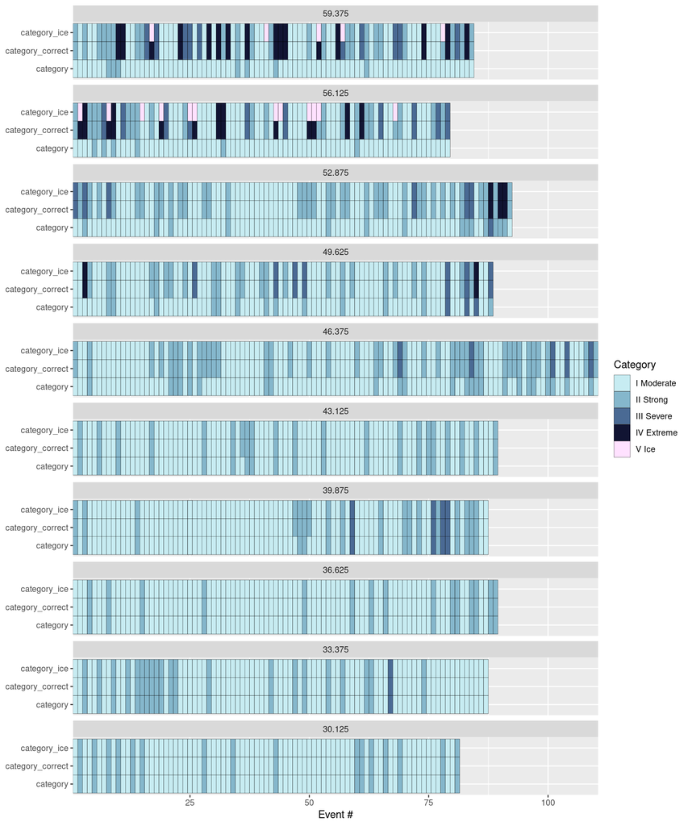

**Figure S2.3:** The effect of the different category methods as one moves north into an area with sea-ice.

```r
# Use Japan ice edge as a surface gradient for some pixels on a latitude transect
cat_base <- readRDS(MCS_lon_files[which(lon_OISST == 147.875)])

# The original MCS methodology
cat_sub <- cat_base %>%
  dplyr::select(-event, -cat_correct) %>%
  unnest(cols = cat) %>%
  filter(row_number() %% 2 == 1) %>%
  filter(nrow(cat$climatology) > 0) %>%
  unnest(cols = cat) %>%
  ungroup() %>%
  filter(t >= "1982-01-01", t <= "2020-12-31",
         lat > 30, lat < 70)

# Those corrected for the 1.8C freezing point
cat_correct_sub <- cat_base %>%
  dplyr::select(-event, -cat) %>%
  unnest(cols = cat_correct) %>%
  filter(row_number() %% 2 == 1) %>%
  filter(nrow(cat_correct$climatology) > 0) %>%
  unnest(cols = cat_correct) %>%
  ungroup() %>%
  filter(t >= "1982-01-01", t <= "2020-12-31",
         lat > 30, lat < 70)

# The categories corrected for near-ice events
cat_ice_ref <- cat_base  %>%
  dplyr::select(-cat, -cat_correct) %>%
  unnest(cols = event) %>%
  filter(row_number() %% 2 == 1) %>%
  unnest(cols = event) %>%
  ungroup() %>%
  filter(thresh < -1.5, event_no > 0,
         t >= "1982-01-01", t <= "2020-12-31",
         lat > 30, lat < 70) %>%
  mutate(ice = TRUE) %>%
  dplyr::select(lon, lat, t, event_no, ice) %>%
  distinct()
cat_ice_sub <- cat_correct_sub %>%
  left_join(cat_ice_ref, by = c("lon", "lat", "t", "event_no")) %>%
  mutate(category_ice = as.character(category),
         category_ice = case_when(ice == TRUE ~ "V Ice",
                                  TRUE ~ category)) %>%
  dplyr::select(-ice, -category)

# Join and exit
MCS_Japan <- left_join(cat_sub, cat_correct_sub,
                       by = c("lon", "lat", "t", "event_no", "intensity")) %>%
  left_join(cat_ice_sub, by = c("lon", "lat", "t", "event_no", "intensity")) %>%
  dplyr::rename(category = category.x, category_correct = category.y)
rm(cat_base, cat_sub, cat_correct_sub, cat_ice_ref, cat_ice_sub)

# Thin out the pixels
sub_lat <- unique(MCS_Japan$lat)[round(seq(1, length(unique(MCS_Japan$lat)), length.out = 10))]

# Rasters showing differences in MCS categories as one moves north
MCS_cat_lat_compare <- MCS_Japan %>%
  filter(lat %in% sub_lat) %>%
  group_by(lon, lat, event_no) %>%
  filter(intensity == min(intensity, na.rm = T)) %>%
  ungroup() %>%
  mutate(lat = factor(lat, levels = rev(unique(lat)))) %>%
  pivot_longer(cols = category:category_ice) %>%
  # ggplot(aes(x = t, y = name)) +
  ggplot(aes(x = event_no, y = name)) +
  # geom_lolli(aes(colour = value)) +
  # geom_point(aes(colour = value), shape = 15) +
  geom_tile(aes(fill = value), colour = "black") +
  scale_fill_manual("Category", values = MCS_colours) +
  scale_colour_manual("Category", values = MCS_colours) +
  scale_x_continuous(expand = c(0, 0)) +
  facet_wrap(~ lat, ncol = 1) +
  labs(x = "Event #", y = NULL)
ggsave("output/MCS_cat_lat_compare.png", MCS_cat_lat_compare, height = 16, width = 16)
MCS_cat_lat_compare
```

Note in the above figure that each panel contains three rows (y-axis), with each row showing the category for a given MCS (x-axis). The label of each panel is the latitude of the results being shown. The further north one moves the more the resultant categories for the different methods begin to diverge from the “original” category method. The purpose of this figure is to highlight how these two proposed fixes to the category issues would have no effect on the vast majority of the ocean. But how much of the ocean exactly would be affected, and how sensitive are these proposed fixes?

## Thinking globally, acting locally

We’ve now provided examples for how to deal with the issues that arise in category detection for MCSs. We’ll end this vignette by looking at what effects these different methods have on a global scale. Up first we have to tally all of the categories of MCSs detected in the global historic database.

```r
# Function for getting the total count of each category per pixel
MCS_cat_count_calc <- function(lon_step){

  # Start
  lon_step_pad <- str_pad(lon_step, 4, pad = "0")
  print(paste0("Began run on ",lon_step," at ", Sys.time()))

  # Load chosen file
  MCS_res <- readRDS(MCS_lon_files[lon_step])

  # Unpack old categories
  MCS_cat <- MCS_res %>%
    dplyr::select(-event, -cat_correct) %>%
    unnest(cols = cat) %>%
    filter(row_number() %% 2 == 0) %>%
    filter(nrow(cat$event) > 0) %>%
    unnest(cols = cat) %>%
    ungroup() %>%
    mutate(method = "old")

  # Unpack new categories
  MCS_cat_correct <- MCS_res %>%
    dplyr::select(-event, -cat) %>%
    unnest(cols = cat_correct) %>%
    filter(row_number() %% 2 == 0) %>%
    filter(nrow(cat_correct$event) > 0) %>%
    unnest(cols = cat_correct) %>%
    ungroup() %>%
    mutate(method = "new")

  # Calculate ice categories from new categories
  MCS_ice_ref <- MCS_res %>%
    dplyr::select(-cat, -cat_correct) %>%
    unnest(cols = event) %>%
    filter(row_number() %% 2 == 1) %>%
    unnest(cols = event) %>%
    ungroup() %>%
    filter(thresh < -1.5, event_no > 0) %>%
    mutate(ice = TRUE) %>%
    dplyr::select(lon, lat, event_no, ice) %>%
    distinct()
  MCS_cat_ice <- MCS_cat_correct %>%
    left_join(MCS_ice_ref, by = c("lon", "lat", "event_no")) %>%
    mutate(method = "ice",
           category = as.character(category),
           category = case_when(ice == TRUE ~ "V Ice",
                                TRUE ~ category)) %>%
    dplyr::select(-ice)
  rm(MCS_res); gc()

  # Combine and process
  MCS_cat_all <- rbind(MCS_cat, MCS_cat_correct, MCS_cat_ice) %>%
    mutate(category = factor(category, levels = c("I Moderate", "II Strong",
                                                  "III Severe", "IV Extreme", "V Ice")),
           season = factor(season, levels = c("Spring", "Summer", "Fall", "Winter"))) %>%
    group_by(lon, lat, method, category) %>%
    mutate(cat_count = n()) %>%
    # pivot_wider(values_from = cat_count, names_from = category)
    ungroup() %>%
    group_by(lon, lat, method, category, cat_count) %>%
    summarise(p_moderate = mean(p_moderate),
              p_strong = mean(p_strong),
              p_severe = mean(p_severe),
              p_extreme = mean(p_extreme), .groups = "drop")
  return(MCS_cat_all)
}

# Calculate global MCS category counts and proportions
registerDoParallel(cores = 50)
system.time(MCS_cat_count <- plyr::ldply(1:1440, MCS_cat_count_calc, .parallel = T, .paropts = c(.inorder = F))) # 222 seconds
saveRDS(MCS_cat_count, "data/MCS_cat_count.Rds")
```

With this tally we can now determine what effect the use of an “Ice” category has. We do this by finding the difference between the count of MCS categories with the original methodology and the “Ice” methodology. Note in the figure below that the primary difference is that in the near-ice areas the majority of the category I events become “Ice” events.

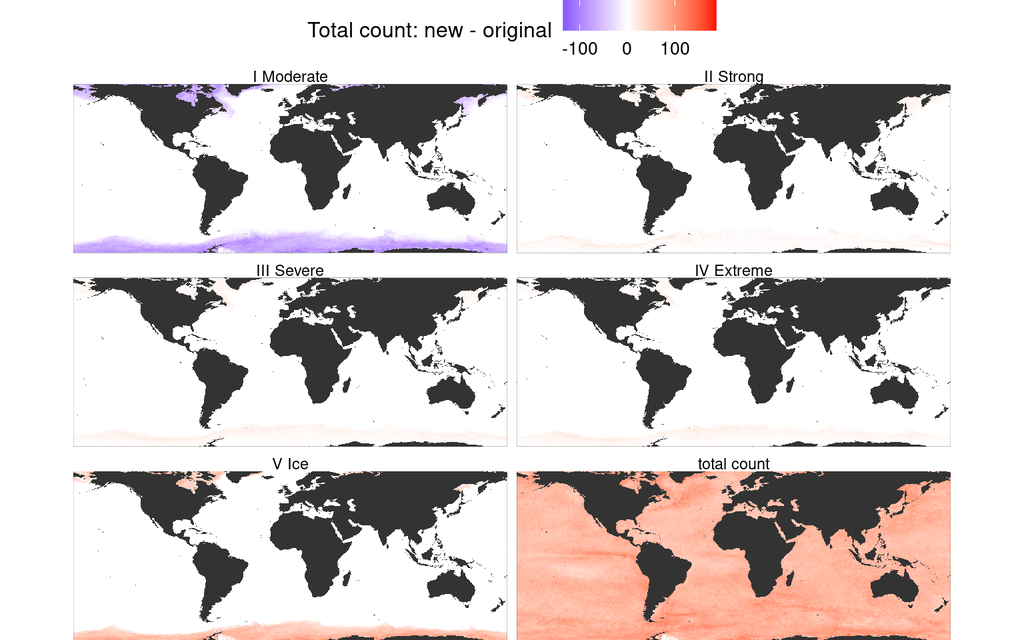

**Figure S3:** The difference in category counts bewteen the original and the ‘Ice’ methodologies. Note that the primary effect is that most category I events in the near-ice regions of the ocean are converted to ‘Ice’ events.

```r
# Prep data for plotting
MCS_cat_count <- readRDS("data/MCS_cat_count.Rds")
MCS_cat_count_n <- MCS_cat_count %>%
  filter(method == "ice") %>%
  mutate(category = "total count") %>%
  group_by(lon, lat, category) %>%
  summarise(diff = sum(cat_count), .groups = "drop")
MCS_cat_count_proc <- MCS_cat_count %>%
  dplyr::select(lon:cat_count) %>%
  pivot_wider(values_from = cat_count, names_from = c(method, category)) %>%
  mutate_all(~replace(., is.na(.), 0)) %>%
  mutate(`I Moderate` = `ice_I Moderate` - `old_I Moderate`,
         `II Strong` = `ice_II Strong` - `old_II Strong`,
         `III Severe` = `ice_III Severe` - `old_III Severe`,
         `IV Extreme` = `ice_IV Extreme` - `old_IV Extreme`,
         `V Ice` = `ice_V Ice`) %>%
  dplyr::select(lon, lat, `I Moderate`:`V Ice`) %>%
  pivot_longer(cols = `I Moderate`:`V Ice`, names_to = "category", values_to = "diff") %>%
  rbind(MCS_cat_count_n) %>%
  mutate(category = factor(category, levels = c("I Moderate", "II Strong", "III Severe",
                                                "IV Extreme", "V Ice", "total count")))

# Four panel map showing difference in count for each pixel per category between old and new methods
MCS_cat_count_diff_map <- MCS_cat_count_proc %>%
  filter(lat >= -70, lat <= 70) %>%
  ggplot(aes(x = lon, y = lat)) +
  geom_tile(aes(fill = diff)) +
  geom_polygon(data = map_base, aes(x = lon, y = lat, group = group)) +
  scale_fill_gradient2("Total count: new - original", low = "blue", high = "red") +
  coord_quickmap(expand = F, ylim = c(-70, 70)) +
  facet_wrap(~category, ncol = 2) +
  theme_void() +
  # guides(fill = guide_legend(override.aes = list(size = 10))) +
  # labs(title = var_name) +
  theme(legend.text = element_text(size = 10),
        legend.title = element_text(size = 12),
        legend.position = "top",
        panel.background = element_rect(fill = "grey90"))
ggsave("output/MCS_cat_count_diff_map.png", MCS_cat_count_diff_map, width = 7, height = 5)
MCS_cat_count_diff_map
```

Note that we have rather arbitrarily chosen -1.5°C as the bottom limit for determining if the category of a MCS is an “Ice” event or not. In the following code we will re-run the “Ice” category threshold on the global data from -1.8°C to 0°C to see how sensitive the global MCS database is to the choice of the “Ice” threshold. Note that these sensitivity tests are being performed on top of the first correction posed in this vignette. That being the adjusting for the categories based on the heard bottom limit of -1.8°C. Remember that the practical effect this has is to exaggerate the detection of category IV events in near-ice areas.

```r
# Function that preps MCS ice cat based on a given threshold
ice_thresh_one <- function(ice_thresh, cat_data){

  # Subset category data only
  cat_correct_sub <- cat_data %>%
    dplyr::select(-event, -cat) %>%
    unnest(cols = cat_correct) %>%
    filter(row_number() %% 2 == 1) %>%
    filter(nrow(cat_correct$climatology) > 0) %>%
    unnest(cols = cat_correct) %>%
    ungroup()

  # Create ice threshold data.frame
  cat_ice_ref <- cat_data  %>%
    dplyr::select(-cat, -cat_correct) %>%
    unnest(cols = event) %>%
    filter(row_number() %% 2 == 1) %>%
    unnest(cols = event) %>%
    ungroup() %>%
    filter(thresh < ice_thresh, event_no > 0) %>%
    mutate(ice = TRUE) %>%
    dplyr::select(lon, lat, t, event_no, ice) %>%
    distinct()
  cat_ice_sub <- cat_correct_sub %>%
    left_join(cat_ice_ref, by = c("lon", "lat", "t", "event_no")) %>%
    mutate(category_ice = as.character(category),
           category_ice = case_when(ice == TRUE ~ "V Ice",
                                    TRUE ~ category),
           ice_thresh = ice_thresh) %>%
    dplyr::select(-ice, -category) %>%
    arrange(lat, t)
  rm(cat_correct_sub, cat_ice_ref); gc()
  return(cat_ice_sub)
}

# Function that loads and preps all MCS data with a given ice threshold
ice_thresh_proc <- function(cat_lon_file, ice_thresh_range){

  # Load the data
  paste0("Began run on ",cat_lon_file)
  cat_data <- readRDS(cat_lon_file)

  # Create a data.frame with multiple ice thresholds
  cat_thresh <- plyr::ldply(seq(ice_thresh_range[1], ice_thresh_range[2], by = 0.1),
                            ice_thresh_one, .parallel = F, cat_data = cat_data)

  # Complete dates by categories data.frame
  full_grid <- expand_grid(t = seq(min(cat_thresh$t, na.rm = T), max(cat_thresh$t, na.rm = T), by = "day"),
                           category_ice = levels(as.factor(cat_thresh$category_ice)),
                           ice_thresh = seq(min(cat_thresh$ice_thresh), max(cat_thresh$ice_thresh), by = 0.1))

  # Calculate total MCS days in the ocean by category
  cat_ocean <- cat_thresh %>%
    dplyr::select(lon, lat, t, category_ice, ice_thresh) %>%
    right_join(lon_lat_OISST_area, by = c("lon", "lat")) %>%
    group_by(t, category_ice, ice_thresh) %>%
    summarise(cat_n = n(),
              cat_area = sum(sq_area), .groups = "drop") %>%
    right_join(full_grid, by = c("t", "category_ice", "ice_thresh")) %>%
    mutate(cat_n = ifelse(is.na(cat_n), 0, cat_n),
           cat_n_prop = round(cat_n/nrow(OISST_ocean_coords), 8),
           cat_area = ifelse(is.na(cat_area), 0, cat_area),
           cat_area_prop = round(cat_area/sum(lon_lat_OISST_area$sq_area), 8),
           year = lubridate::year(t)) %>%
    arrange(t, category_ice, ice_thresh) %>%
    group_by(year, category_ice, ice_thresh) %>%
    mutate(cat_n_cum = cumsum(cat_n),
           cat_area_cum = cumsum(cat_area),
           cat_n_cum_prop = round(cat_n_cum/nrow(OISST_ocean_coords), 8),
           cat_area_cum_prop = round(cat_area_cum/sum(lon_lat_OISST_area$sq_area), 8)) %>%
    ungroup() %>%
    dplyr::select(-year)

  # Final results
  cat_final <- cat_ocean  %>%
    filter(lubridate::month(t) == 12, lubridate::day(t) == 31) %>%
    mutate(t = lubridate::year(t))

  # Clean and exit
  rm(cat_data, cat_thresh, full_grid, cat_ocean); gc()
  return(cat_final)
}

# Function for calculating global MCS results with a moving Ice category threshold
ice_thresh_full <- function(ice_thresh_range){

  # First run this on all of the MCS lon files
  # system.time(
  ice_data_full <- plyr::ldply(MCS_lon_files, ice_thresh_proc, .parallel = T,
                               ice_thresh_range = ice_thresh_range)
  # ) # 56 seconds for 1, 63 seconds for 5

  # Add lon results together
  ice_data_sum <- ice_data_full %>%
    group_by(t, category_ice, ice_thresh) %>%
    summarise_all(sum)

  # save and exit
  write_rds(ice_data_sum, "data/MCS_ice_thresh_test.Rds")
}

# Run the analysis
registerDoParallel(cores = 25)
ice_thresh_full(c(-1.8, 0))
```

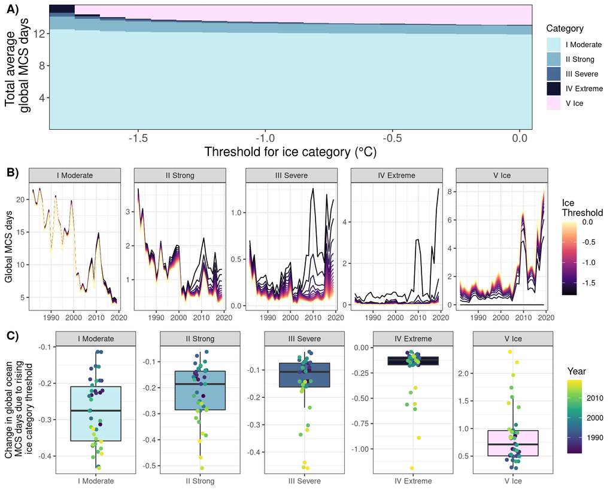

**Figure S4:** Global sensitivity analysis of ‘Ice’ category threshold choice. A) The total average of all MCS days ever recorded for each category (y-axis) depending on the threshold choice for the ‘Ice’ category (x-axis). Note that at a value of -1.8 there are no ‘Ice’ category events, just a lot of category IV events. Also note that, generally speaking, the choice of threshold is not very sensitive. B) The average MCS days (y-axis) per year (x-axis) depending on the choice of ‘Ice’ threshold (line colour). The different categories are shown in different facets. Mote how lare the effect is on the more intense categories when moving from -1.8 to -1.7 to -1.6. C) These boxplots show the several facets of information simultaneously. Note that the y-axes differ, and each facet shows a different category. The data points in the boxplots are the trends (linear model) in the change in the count of days in a given year per 0.1C step difference in the ice category threshold (similar to panel A). The individual points in the boxplots show the data for each year. Note that the more recent years tend to experience stronger impacts of the ‘Ice’ category method.

```r
# Load all results and plot them
ice_thresh_all <- read_rds("data/MCS_ice_thresh_test.Rds")

# Overall summary
ice_thresh_fig_a <- ice_thresh_all %>%
  group_by(ice_thresh, category_ice) %>%
  summarise(mean_cum_area_prop = mean(cat_area_cum_prop), .groups = "drop") %>%
  ggplot(aes(x = ice_thresh, y = mean_cum_area_prop)) +
  geom_bar(aes(fill = category_ice), stat = "identity", show.legend = T,
           position = position_stack(reverse = TRUE), width = 0.1) +
  scale_fill_manual("Category", values = MCS_colours) +
  scale_y_continuous(breaks = c(4, 8, 12)) +
  labs(y = "Total average \n global MCS days", x = "Threshold for ice category (°C)") +
  coord_cartesian(expand = F) +
  theme_bw() +
  theme(panel.border = element_rect(colour = "black", fill = NA),
        axis.title = element_text(size = 15),
        axis.text = element_text(size = 13))
# ice_thresh_fig_a

# Time series figure showing how proportions of MCS days change over years from threshold choice
ice_thresh_fig_b <- ice_thresh_all %>%
  ggplot() +
  geom_line(aes(x = t, y = cat_area_cum_prop, colour = ice_thresh, group = ice_thresh)) +
  scale_colour_viridis_c("Ice\nThreshold", option = "A") +
  facet_wrap(~category_ice, scales = "free", nrow = 1) +
  labs(x = NULL, y = "Global MCS days") +
  theme_bw()
# ice_thresh_fig_b

# Create figure with the values per year as slope of linear model of change in category as threshold decreases
ice_thresh_fig_c <- ice_thresh_all %>%
  group_by(t, category_ice) %>%
  do(fit_cat = broom::tidy(lm(cat_area_cum_prop ~ ice_thresh, data = .))) %>%
  unnest(fit_cat) %>%
  filter(term == "ice_thresh") %>%
  ggplot() +
  geom_boxplot(aes(x = category_ice, y = estimate, fill = category_ice),
               outlier.colour = NA, show.legend = F) +
  geom_jitter(aes(x = category_ice, y = estimate, colour = t), width = 0.1) +
  scale_fill_manual("Category", values = MCS_colours) +
  scale_colour_viridis_c("Year") +
  facet_wrap(~category_ice, scales = "free", nrow = 1) +
  labs(x = NULL, y = "Change in global ocean\n MCS days due to rising\n ice category threshold") +
  theme_bw()
# ice_thresh_fig_c

# Combine and save
ice_thresh_fig <- ggpubr::ggarrange(ice_thresh_fig_a, ice_thresh_fig_b, ice_thresh_fig_c,
                                    ncol = 1, labels = c("A)", "B)", "C)"))
ggsave("output/MCS_ice_thresh_test.png", ice_thresh_fig, height = 8, width = 12)
ice_thresh_fig
```

WHile this figure is very complex, I think that it ultimately makes the case for an “Ice” threshold choice of of somewhere between -1.7°C to -1.4°C, depending on one’s use and the desired clarity of outcome. I know that isn’t very exact advice, but remember that at the outset of this vignette it was stated up front that these possible fixes to the methodology were just that, possibilities. The authors ultimately decided that these changes to the category detection introduced more complexity than they were worth. At least on a global context and for any comparability to MHW results. We can however certainly see use cases for the MCS algorithm in which one may want to use these fixes and so we hope that this vignette may serve as a resource to someone at some point.

## References

Hobday, Alistair J., Lisa V. Alexander, Sarah E. Perkins, Dan A. Smale, Sandra C. Straub, Eric C. J. Oliver, Jessica A. Benthuysen, et al. 2016. “A hierarchical approach to defining marine heatwaves.” *Progress in Oceanography* 141: 227–38. https://doi.org/10.1016/j.pocean.2015.12.014.

Hobday, Alistair J., Eric C. J. Oliver, Alex Sen Gupta, Jessica A. Benthysen, Michael T. Burrows, Markus G. Donat, Neil J. Holbrook, et al. 2018. “Categorizing and naming marine heatwaves.” *Oceanography* 31 (2). https://doi.org/10.5670/oceanog.2018.205.